# Are Players Getting Paid Accurately

## Pitching Models

```
Random Forest Pitching Model Performance:
Accuracy: 0.66
ROC AUC Score: 0.60
F1 Score: 0.06

Classification Report:
              precision    recall  f1-score   support

           0       0.66      0.98      0.79        60
           1       0.50      0.03      0.06        31

    accuracy                           0.66        91
   macro avg       0.58      0.51      0.43        91
weighted avg       0.61      0.66      0.54        91
```

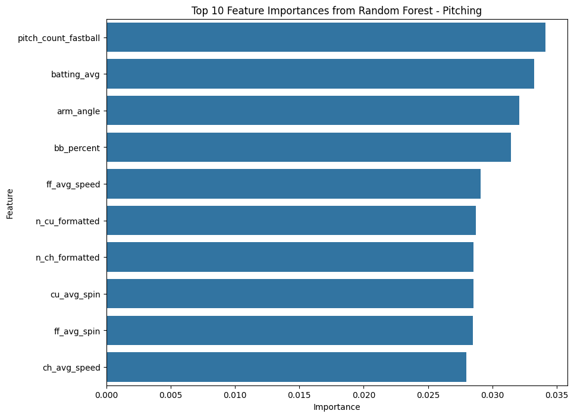

```python
# Ensure target variable and features have no missing values

merged_pitching = merged_pitching.dropna(subset=['top_earner'])

# Define X (features) and y (target)
X_pitching = merged_pitching.drop(columns=['top_earner', 'value'])
y_pitching = merged_pitching['top_earner']  # Define the target variable

# Check for non-numeric columns in X_pitching
non_numeric_columns = X_pitching.select_dtypes(exclude=['number']).columns


# Drop non-numeric columns to ensure only numeric data remains
X_pitching = X_pitching.select_dtypes(include=['number'])


# Re-run the train-test split with the cleaned data
X_train, X_test, y_train, y_test = train_test_split(X_pitching, y_pitching, test_size=0.2, random_state=42)

# Initialize and train the Random Forest model
rf_model = RandomForestClassifier(random_state=42)
rf_model.fit(X_train, y_train)

# Predict on the test set
y_pred = rf_model.predict(X_test)
y_pred_proba = rf_model.predict_proba(X_test)[:, 1]

# Evaluate the model
accuracy = accuracy_score(y_test, y_pred)
roc_auc = roc_auc_score(y_test, y_pred_proba)
f1 = f1_score(y_test, y_pred)

print("Random Forest Pitching Model Performance:")
print(f"Accuracy: {accuracy:.2f}")
print(f"ROC AUC Score: {roc_auc:.2f}")
print(f"F1 Score: {f1:.2f}")
print("\nClassification Report:")
print(classification_report(y_test, y_pred))

# Feature Importance
feature_importances = rf_model.feature_importances_
features = X_pitching.columns

# Plot feature importance
importance_df = pd.DataFrame({'Feature': features, 'Importance': feature_importances})
importance_df = importance_df.sort_values(by='Importance', ascending=False)

plt.figure(figsize=(10, 8))
sns.barplot(x='Importance', y='Feature', data=importance_df.head(10))  # Top 10 important features
plt.title("Top 10 Feature Importances from Random Forest - Pitching")
plt.show()
```

### Gradient Boost Pitching

```python
# Define thresholds to experiment with
thresholds = [0.005, 0.01, 0.02]
performance_metrics = []

# Split the data into training and test sets (e.g., 80% train, 20% test)
X_pitching = merged_pitching.drop(columns=['top_earner', 'value'])
y_pitching = merged_pitching['top_earner']
X_train_full, X_test, y_train_full, y_test = train_test_split(X_pitching, y_pitching, test_size=0.2, random_state=42)

# Loop through each threshold
for threshold in thresholds:
    # Filter features based on the importance threshold from Random Forest
    important_features = importance_df[importance_df['Importance'] >= threshold]['Feature'].tolist()
    X_train_selected = X_train_full[important_features]

    # Cross-validation to measure performance on the training data with the selected features
    gb_model = GradientBoostingClassifier(random_state=42)
    cv_scores = cross_val_score(gb_model, X_train_selected, y_train_full, cv=5, scoring='roc_auc')
    avg_cv_score = np.mean(cv_scores)

    # Fit Gradient Boosting on the full training set with selected features
    gb_model.fit(X_train_selected, y_train_full)

    # Store performance metrics for each threshold
    performance_metrics.append({
        'Threshold': threshold,
        'Features Used': len(important_features),
        'Average CV ROC AUC': avg_cv_score
    })

# Convert to DataFrame for easy viewing
performance_df = pd.DataFrame(performance_metrics)
print("Performance on Training Data (using Cross-Validation):")
print(performance_df)

# Choose the threshold that provided the best cross-validation performance
best_threshold = performance_df.loc[performance_df['Average CV ROC AUC'].idxmax(), 'Threshold']
best_features = importance_df[importance_df['Importance'] >= best_threshold]['Feature'].tolist()
print(f"\nBest threshold: {best_threshold} with features: {best_features}")

# Final Model Training and Evaluation on Test Set with the Best Threshold
X_train_best = X_train_full[best_features]
X_test_best = X_test[best_features]

# Train Gradient Boosting on the entire training data with the best feature subset
gb_final_model = GradientBoostingClassifier(random_state=42)
gb_final_model.fit(X_train_best, y_train_full)

# Predict on the test set
y_pred = gb_final_model.predict(X_test_best)
y_pred_proba = gb_final_model.predict_proba(X_test_best)[:, 1]

# Evaluate the final model on the test set
accuracy = accuracy_score(y_test, y_pred)
roc_auc = roc_auc_score(y_test, y_pred_proba)
f1 = f1_score(y_test, y_pred)

print("\nFinal Gradient Boosting Model Performance on Test Set:")
print(f"Accuracy: {accuracy:.2f}")
print(f"ROC AUC Score: {roc_auc:.2f}")
print(f"F1 Score: {f1:.2f}")
print("\nClassification Report:")
print(classification_report(y_test, y_pred))
```

```
Performance on Training Data (using Cross-Validation):
   Threshold  Features Used  Average CV ROC AUC
0      0.005             42            0.602759
1      0.010             42            0.602759
2      0.020             30            0.632103

Best threshold: 0.02 with features: ['pitch_count_fastball', 'batting_avg', 'arm_angle', 'bb_percent', 'ff_avg_speed', 'n_cu_formatted', 'n_ch_formatted', 'cu_avg_spin', 'ff_avg_spin', 'ch_avg_speed', 'n', 'pa', 'n_sl_formatted', 'pitch_count', 'barrel', 'solidcontact_percent', 'swing_percent', 'z_s…

Final Gradient Boosting Model Performance on Test Set:
Accuracy: 0.66
ROC AUC Score: 0.61
F1 Score: 0.11

Classification Report:
              precision    recall  f1-score   support

           0       0.67      0.97      0.79        60
           1       0.50      0.06      0.11        31

    accuracy                           0.66        91
   macro avg       0.58      0.52      0.45        91
weighted avg       0.61      0.66      0.56        91
```

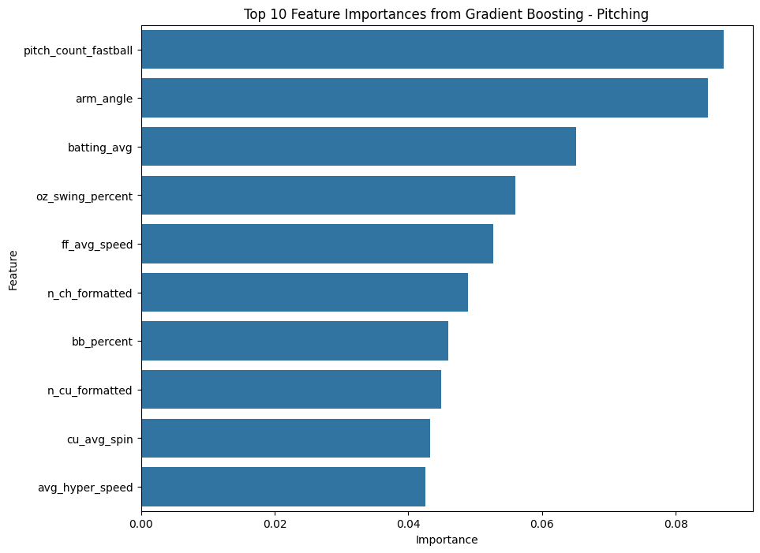

[figure not shown]

```python
# Extract feature importances and sort them in descending order
feature_importances = gb_final_model.feature_importances_
features = X_train_best.columns

# Create a DataFrame for feature importances
importance_df = pd.DataFrame({'Feature': features, 'Importance': feature_importances})
importance_df = importance_df.sort_values(by='Importance', ascending=False)

# 1. Bar Plot of Top 10 Feature Importances
plt.figure(figsize=(10, 8))
sns.barplot(x='Importance', y='Feature', data=importance_df.head(10))
plt.title("Top 10 Feature Importances from Gradient Boosting - Pitching")
plt.xlabel("Importance")
plt.ylabel("Feature")
plt.show()

# 2. Cumulative Feature Importance Plot
importance_df['Cumulative Importance'] = importance_df['Importance'].cumsum()
plt.figure(figsize=(10, 6))
plt.plot(importance_df['Cumulative Importance'], marker='o', color='b')
plt.xlabel("Number of Features")
plt.ylabel("Cumulative Importance")
plt.title("Cumulative Feature Importance - Pitching")
plt.axhline(y=0.9, color='r', linestyle='--', label='90% Cumulative Importance')
plt.legend()
plt.show()
```

The feature importance rankings for the Gradient Boosting and Random Forest models on the pitching dataset show some commonalities but also notable differences. Both models identify pitch_count_fastball as the most influential feature, indicating its strong predictive value for distinguishing top earners among pitchers. Other shared key features include batting_avg, arm_angle, bb_percent (walk rate), and ff_avg_speed (fastball average speed), suggesting that these metrics consistently play a critical role across both algorithms.